# exercise_sheet_2.R

Chris

2022-11-10

### Imports

```r
library("mlr3")
library("ggplot2")
library("mlr3learners")
library("mlr3viz")
```

### Task 1

#### b)

Have a look at mlr3::tsk(“iris”). What attributes does this task object store?

```r
(task = mlr3::tsk("iris"))
```

```
## <TaskClassif:iris> (150 x 5): Iris Flowers
## * Target: Species
## * Properties: multiclass
## * Features (4):
##   - dbl (4): Petal.Length, Petal.Width, Sepal.Length, Sepal.Width
```

The task object stores: * 150x5 data set of iris flowers * Target variable: species * Propertiers: multiclass * 4 Features (dbl): - Petal.Length - Petal.Width - Sepal.Length - Sepal.Width #### c) Pick an mlr3 learner of your choice. What are the different settings for this learner?

```r
learner = lrn("classif.rpart")

# different settings:
learner$param_set
```

```
## <ParamSet>
##                 id    class lower upper nlevels        default value
##  1:             cp ParamDbl     0     1     Inf           0.01
##  2:     keep_model ParamLgl    NA    NA       2          FALSE
##  3:     maxcompete ParamInt     0   Inf     Inf              4
##  4:       maxdepth ParamInt     1    30      30             30
##  5:   maxsurrogate ParamInt     0   Inf     Inf              5
##  6:      minbucket ParamInt     1   Inf     Inf <NoDefault[3]>
##  7:       minsplit ParamInt     1   Inf     Inf             20
##  8: surrogatestyle ParamInt     0     1       2              0
##  9:   usesurrogate ParamInt     0     2       3              2
## 10:           xval ParamInt     0   Inf     Inf             10     0
```

### Task 3

Simulate data

```r
set.seed(7L)
x <- seq(from = -2.5, to = 2.5, by =0.25)
y <- -3 + 5 * sin(0.4 * pi * x) + rnorm(n = length(x), mean = 0, sd = 1)
data <- data.frame(x, y)
```

```r
X <- as.matrix(sapply(seq(0, 3), function(i) x^i))
head(X)
```

```
##      [,1]  [,2]   [,3]       [,4]
## [1,]    1 -2.50 6.2500 -15.625000
## [2,]    1 -2.25 5.0625 -11.390625
## [3,]    1 -2.00 4.0000  -8.000000
## [4,]    1 -1.75 3.0625  -5.359375
## [5,]    1 -1.50 2.2500  -3.375000
## [6,]    1 -1.25 1.5625  -1.953125
```

Create 3 different feature-combinations

```r
feature_vec <- matrix(
  rbind(
    c(1, 1, 1, 1),
    c(0, -1, 0.2, 0.25),
    c(1, 0.025, 2, 0)
  ),
  nrow = 3
)
feature_vec
```

```
##      [,1]   [,2] [,3] [,4]
## [1,]    1  1.000  1.0 1.00
## [2,]    0 -1.000  0.2 0.25
## [3,]    1  0.025  2.0 0.00
```

Compute model outputs for each feature-combination

```r
f_est <- sapply(1:3, function(i) X %*% feature_vec[i, ])
data_est_models <- data.frame(x, f_est)
names(data_est_models) <- c("x", "f1", "f2", "f3")
head(data_est_models)
```

```
##       x         f1         f2       f3
## 1 -2.50 -10.875000 -0.1562500 13.43750
## 2 -2.25  -7.578125  0.4148438 11.06875
## 3 -2.00  -5.000000  0.8000000  8.95000
## 4 -1.75  -3.046875  1.0226562  7.08125
## 5 -1.50  -1.625000  1.1062500  5.46250
## 6 -1.25  -0.640625  1.0742188  4.09375
```

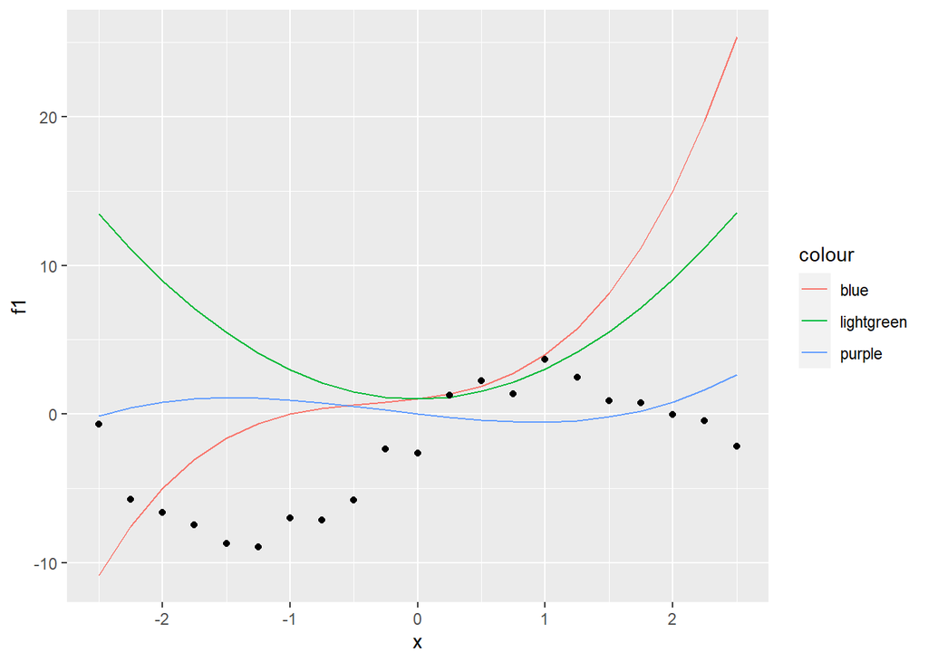

```r
ggplot(data_est_models) +
  geom_line(mapping = aes(x = x, y = f1, col = "blue")) +
  geom_line(mapping = aes(x = x, y = f2, col = "purple")) +
  geom_line(mapping = aes(x = x, y = f3, col = "lightgreen")) +
  geom_point(data = data, mapping = aes(x = x, y = y))
```

### Task 4

We want to predict the age of an abalone using its longest shell measurement and its weight See https://archive.ics.uci.edu/ml/machine-learning-databases/abalone/ for more details.

```r
url <- "https://archive.ics.uci.edu/ml/machine-learning-databases/abalone/abalone.data"
abalone <- read.table(url, sep = ",", row.names = NULL)
colnames(abalone) <- c(
  "sex", "longest_shell", "diameter", "height", "whole_weight",
  "shucked_weight", "visceral_weight", "shell_weight", "rings")
abalone <- abalone[, c("longest_shell", "whole_weight", "rings")]
```

#### a)

Plot LongestShell and WholeWeight on the x- and y-axis, respectively, and color points according to Rings.

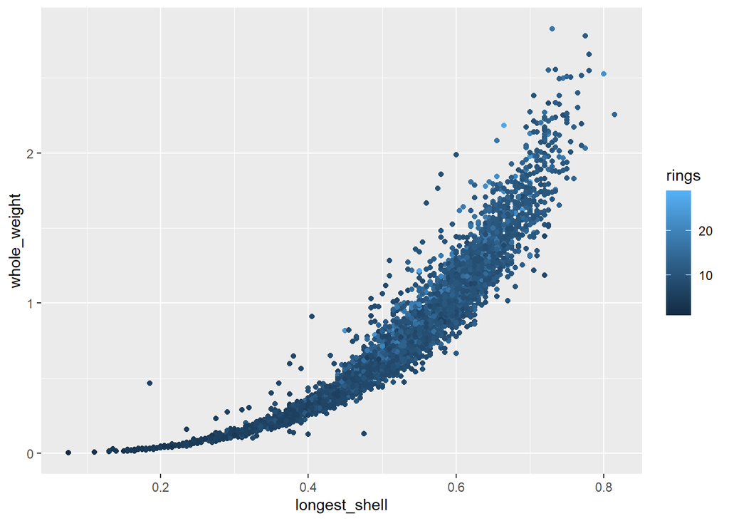

```r
ggplot(data = abalone, mapping = aes(x = longest_shell,
                                     y = whole_weight,
                                     color = rings)) +
  geom_point()
```

#### b)

Create an mlr3 task for the abalone data.

```r
task_abalone = TaskRegr$new("abalone", abalone, "rings")
task_abalone
```

```
## <TaskRegr:abalone> (4177 x 3)
## * Target: rings
## * Properties: -
## * Features (2):
##   - dbl (2): longest_shell, whole_weight
```

#### c)

Define a linear regression learner (for this you will need to load the mlr3learners extension package frst) and use it to train a linear model on the abalone data.

```r
mlr_learners_table = as.data.table(mlr_learners)
mlr_learners_table[16:nrow(mlr_learners_table), c("key", "packages", "predict_types")]
```

```
##                  key                      packages predict_types
##  1:   regr.cv_glmnet      mlr3,mlr3learners,glmnet      response
##  2:       regr.debug                          mlr3   response,se
##  3: regr.featureless                    mlr3,stats   response,se
##  4:      regr.glmnet      mlr3,mlr3learners,glmnet      response
##  5:        regr.kknn        mlr3,mlr3learners,kknn      response
##  6:          regr.km mlr3,mlr3learners,DiceKriging   response,se
##  7:          regr.lm       mlr3,mlr3learners,stats   response,se
##  8:        regr.nnet        mlr3,mlr3learners,nnet      response
##  9:      regr.ranger      mlr3,mlr3learners,ranger   response,se
## 10:       regr.rpart                    mlr3,rpart      response
## 11:         regr.svm       mlr3,mlr3learners,e1071      response
## 12:     regr.xgboost     mlr3,mlr3learners,xgboost      response
```

Learner

```r
learner_ablaone = lrn("regr.lm")
learner_ablaone$train(task_abalone)
```

Prediction

```r
pred_lm <- learner_ablaone$predict(task_abalone)
head(data.frame(
  id = 1:length(pred_lm$truth),
  truth = pred_lm$truth,
  response = pred_lm$response))
```

```
##   id truth response
## 1  1    15 8.840042
## 2  2     7 7.395659
## 3  3     9 9.821995
## 4  4    10 8.683616
## 5  5     7 7.160333
## 6  6     8 8.334876
```

#### d)

Compare the fitted and observed targets visually.

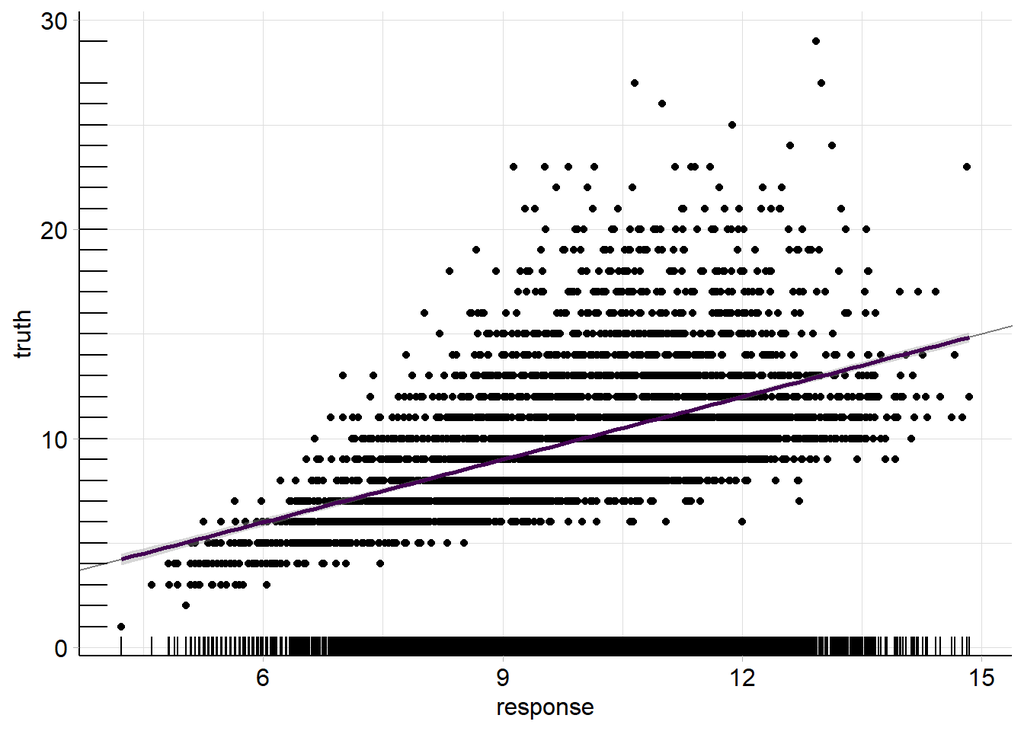

```r
mlr3viz::autoplot(pred_lm)
```

Scatterplot of true vs. response (predicted) values. The relationship doesn’t look strictly linear. Coefficients

```r
print(learner_ablaone$model$coefficients)
```

```
##   (Intercept) longest_shell  whole_weight
##      3.431349     10.582428      1.155035
```

#### e)

Assess the model’s training loss in terms of MAE.

```r
# MAE metric
mae <- mlr3::msr("regr.mae")

# performance scores
pred_lm$score() # MSE
```

```
## regr.mse
## 7.125521
```

```r
pred_lm$score(mae)
```

```
## regr.mae
##  1.95066
```